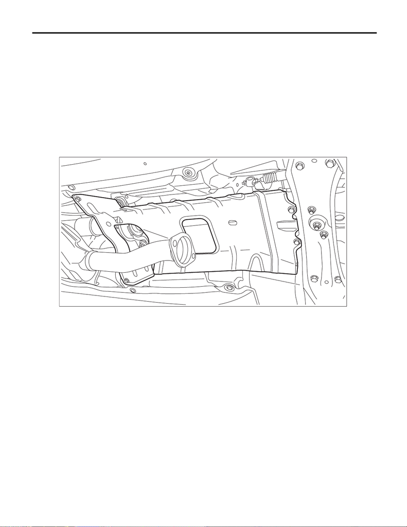

CVT(TR690)-87

Extension Case Oil Seal

CONTINUOUSLY VARIABLE TRANSMISSION

12.Extension Case Oil Seal

A: INSPECTION

Check for leakage of CVTF from the joint section of transmission and propeller shaft. If a leak is found, in-

spect the propeller shaft and replace the oil seal.

B: REPLACEMENT

CAUTION:

1) Lift up the vehicle.

2) Clean the transmission exterior.

3) Remove the center exhaust pipe (rear). <Ref. to EX(w/o STI)-35, REMOVAL, Center Exhaust Pipe.>

4) Remove the center exhaust cover.

5) Remove the propeller shaft. <Ref. to DS-12, REMOVAL, Propeller Shaft.>

6) Using a screwdriver or ST, remove the oil seal trying not to damage the extension case.

ST 398527700 PULLER ASSY

7) Using the ST, install the oil seal.

NOTE:

Use a new oil seal.

ST 498057300 OIL SEAL DRIFT

AT-07743

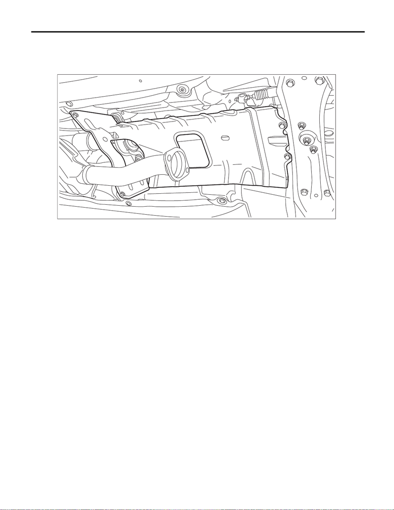

CVT(TR690)-88

Extension Case Oil Seal

CONTINUOUSLY VARIABLE TRANSMISSION

8) Install the propeller shaft. <Ref. to DS-14, INSTALLATION, Propeller Shaft.>

9) Install the center exhaust cover.

Tightening torque:

18 N·m (1.8 kgf-m, 13.3 ft-lb)

10) Install the center exhaust pipe (rear). <Ref. to EX(w/o STI)-41, INSTALLATION, Center Exhaust Pipe.>

11) Adjust the CVTF level and check there is no leakage. <Ref. to CVT(TR690)-36, ADJUSTMENT, CVTF.>

AT-07743